# EPIGENOMICS PRACTICAL EXERCISE

DNA Methylation Report

Marina Vilardell

2023-03-14

# 1 Introduction

The goal of this practical is to analyse a data set that contains information about Crohn’s disease, an autoimmune disease which affects colon and intestine. In the data there are patients and healthy controls coming from adipose cells with an EPIC array.

We will see how to read input raw data (iDAT files), how to perform the quality control to identify those samples and probes that are considered to be removed, sex prediction, normalization of the data and removal of some CpG sites, identify the differentially methylated CpG positions between crohn’s disease and healthy samples, and finally to perform an enrichment analysis to identify which biological pathways are over represented in the differentially methylated CpGs.

## 1.1 Libraries

These are the libraries needed for the properly analysis of methylation.

```r
# ------------ Libraries ------------
library(minfi)
library(IlluminaHumanMethylationEPICanno.ilm10b4.hg19)
library(DMRcate)
library(FactoMineR)
```

## 1.2 EPIC array

The infinium methylation EPIC array, produced by Illumina, gives information for over 850.000 CpG islands throughout the human genome. Each sample will be measured in a single array, and in tho different color channels, green and red.

There are two types of probes used in this array: Type I and type II probes, and for each CpG we will have two measurements: methylated intensity and unmethylated intensity. Using this values, the methylation level of each CpG can be calculated, which is reported as the Beta-values (ratio of methylated probe intensity versus the overall intensity). The difference between the type of probes is that the type I probe require two beads for each locus, and type II only requires one bead per locus, as it is seen in the following figure.

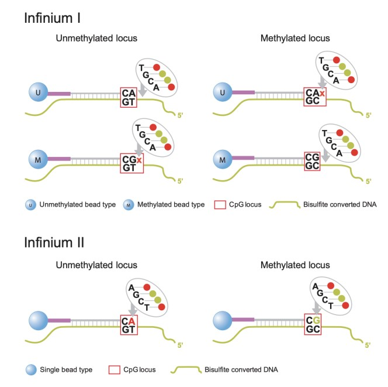

Type I and type II probes.

Previously in the laboratory, genomic DNA samples are treated with a bisulfite treatment, used to identify and quantify the methylated cytosines in the DNA. If the cytosine is methylated, it will remain cytosine, but if the cytosine is not methylated, then it will change to uracil. When amplifying, the uracils will be transformed to thymine, and for sure the cytosines we get will be methylated. Then, it will be fragmented, hybridized and finally scanned.

To measure the methylation levels, we will get the beta values which range between 0 and 1. As we are not analyzing single-cell methylation, the beta values will be an average of the methylated base for that probe, for all the cells found in the sample. A value of 0 indicates that all the copies of the CpG site of all the cells in the sample were unmethylated, whereas a value of 1 inficates that all the cells have the specific CpG site methylated. In the reality, it is uncommon to find those extreme values, due to the technical noise and other type of variations, so the beta-values commonly lie between 0.1-0.9 range.

M-values are also another metric to measure methylation levels (which will be used in this practical), and they are the log2 ratio of the methylated probe versus the unmethylated.

# 2 Reading data

Methylation data is stored in IDAT files. To import this data in R, we will use some functions of the **minfi** package. First of all, we specify the path to the IDAT files and a sample sheet, which contains some information regarding each of the samples used in this experiment.

```r
# ----- set working directory and path to folder ----
setwd("C:/Users/MARINA/Documents/MASTER/EPIGENOMICS/Ilumina_data_analysis/Practical")
idat.folder <- "/Users/MARINA/Documents/MASTER/EPIGENOMICS/Ilumina_data_analysis/Practical"

# --- read the sample sheet ---
targets <- read.metharray.sheet(base=idat.folder)
```

```
## [1] "/Users/MARINA/Documents/MASTER/EPIGENOMICS/Ilumina_data_analysis/Practical/targets.csv"
```

```r
targets
```

```
##             X                   title SampleName patient.diagnosis.ch1
## 1  GSM4105187 CD1_201105980145_R04C01 GSM4105187       Crohn's Disease
## 2  GSM4105188 CD2_201105980145_R05C01 GSM4105188       Crohn's Disease
## 3  GSM4105189 CD3_201105980145_R06C01 GSM4105189       Crohn's Disease
## 4  GSM4105190 CD4_201105980145_R07C01 GSM4105190       Crohn's Disease
## 5  GSM4105191 CD5_201105980145_R08C01 GSM4105191       Crohn's Disease
## 6  GSM4105192 CD6_201105980146_R01C01 GSM4105192       Crohn's Disease
## 7  GSM4105193 CD7_201105980146_R02C01 GSM4105193       Crohn's Disease
## 8  GSM4105194  N1_201105980146_R03C01 GSM4105194    No Crohn's Disease
## 9  GSM4105195  N2_201105980146_R04C01 GSM4105195    No Crohn's Disease
## 10 GSM4105196  N3_201105980146_R05C01 GSM4105196    No Crohn's Disease
## 11 GSM4105197  N4_201105980146_R06C01 GSM4105197    No Crohn's Disease
## 12 GSM4105198  N5_201105980146_R07C01 GSM4105198    No Crohn's Disease
## 13 GSM4105199  N6_201105980146_R08C01 GSM4105199    No Crohn's Disease
##                              Basename
## 1  GSM4105187_CD1_201105980145_R04C01
## 2  GSM4105188_CD2_201105980145_R05C01
## 3  GSM4105189_CD3_201105980145_R06C01
## 4  GSM4105190_CD4_201105980145_R07C01
## 5  GSM4105191_CD5_201105980145_R08C01
## 6  GSM4105192_CD6_201105980146_R01C01
## 7  GSM4105193_CD7_201105980146_R02C01
## 8   GSM4105194_N1_201105980146_R03C01
## 9   GSM4105195_N2_201105980146_R04C01
## 10  GSM4105196_N3_201105980146_R05C01
## 11  GSM4105197_N4_201105980146_R06C01
## 12  GSM4105198_N5_201105980146_R07C01
## 13  GSM4105199_N6_201105980146_R08C01
```

The data set contains 13 samples. 7 correspond to Crohn’s Disease patients and 6 to healthy patients.

Once this is done, we now can read the raw intensity data using the function *read.methylation.exp()*, which will create a RGChannel object.

```r
# ---- loading data ----
rgset <- read.metharray.exp(targets = targets,verbose = T)
rgset # EPIC array
```

```
## class: RGChannelSet
## dim: 1052641 13
## metadata(0):
## assays(2): Green Red
## rownames(1052641): 1600101 1600111 ... 99810990 99810992
## rowData names(0):
## colnames(13): GSM4105187_CD1_201105980145_R04C01
##   GSM4105188_CD2_201105980145_R05C01 ...
##   GSM4105198_N5_201105980146_R07C01 GSM4105199_N6_201105980146_R08C01
## colData names(6): X title ... Basename filenames
## Annotation
##   array: IlluminaHumanMethylationEPIC
##   annotation: ilm10b4.hg19
```

```r
colnames(rgset)
```

```
##  [1] "GSM4105187_CD1_201105980145_R04C01" "GSM4105188_CD2_201105980145_R05C01"
##  [3] "GSM4105189_CD3_201105980145_R06C01" "GSM4105190_CD4_201105980145_R07C01"
##  [5] "GSM4105191_CD5_201105980145_R08C01" "GSM4105192_CD6_201105980146_R01C01"
##  [7] "GSM4105193_CD7_201105980146_R02C01" "GSM4105194_N1_201105980146_R03C01"
##  [9] "GSM4105195_N2_201105980146_R04C01"  "GSM4105196_N3_201105980146_R05C01"
## [11] "GSM4105197_N4_201105980146_R06C01"  "GSM4105198_N5_201105980146_R07C01"
## [13] "GSM4105199_N6_201105980146_R08C01"
```

```r
#Change the name of the samples, to easly identify them. To do this, remove from _2011 to the end.
#CD are Crohn's disease samples and N are healthy samples.
colnames(rgset)<-sub("_2011.*", "", colnames(rgset))
```

rgset is a RGChannelSet object where we have the RAW DATA. This is the initial object of a minfi analysis that contains the raw intensities in the green and red channels, and also intensities of the internal control probes. As the data is read from a data sheet, the phenotype data is also stored in the rgset object and can be accessed with the command *pdata()*.

```r
# --- Data exploration ----
# Extract phenodata
phenoData <- pData(rgset)
#The RGChannelSet stores also a manifest object that contains the probe design information of the array:

manifest <- getManifest(rgset)
manifest #EPIC array and type of probes
```

```
## IlluminaMethylationManifest object
## Annotation
##   array: IlluminaHumanMethylationEPIC
## Number of type I probes: 142262
## Number of type II probes: 724574
## Number of control probes: 635
## Number of SNP type I probes: 21
## Number of SNP type II probes: 38
```

- Total number of initial probes: 866836
- Number of initial samples: 13

```r
####Probes information
getProbeInfo(manifest, type = "I")
```

```
## DataFrame with 142262 rows and 8 columns
##               Name    AddressA    AddressB       Color       NextBase
##        <character> <character> <character> <character> <DNAStringSet>
## 1       cg18478105    46761277    86644198         Grn              C
## 2       cg09835024    16745152    81631976         Red              A
## 3       cg14361672    51800947     7743487         Red              T
## 4       cg01763666    37768834    23754592         Grn              C
## 5       cg12950382     8726444    76660327         Red              A
## ...            ...         ...         ...         ...            ...
## 142258  cg06899844    58695205    89635329         Red              A
## 142259  cg22494081     5672534    22760897         Red              A
## 142260  cg22623303    56736111    11616883         Red              T
## 142261  cg12325588    78754334    35621935         Grn              C
## 142262  cg21064505    92700227    55789279         Red              T
##                      ProbeSeqA               ProbeSeqB      nCpG
##                 <DNAStringSet>          <DNAStringSet> <integer>
## 1      AAATAAATTT...ACAAAAACCA AAATAAATTT...ACGAAAACCG         5
## 2      AATAAACACC...ACAAAAATCA AATAAACGCC...ACAAAAATCG         5
## 3      ATCACTACCT...ACATCCTACA ATCACTACCT...ACATCCTACG         2
## 4      AAACAAAAAT...AAAACAAACA GAACAAAAAT...AAAACAAACG         1
## 5      ATACCAAAAA...CCAAATAACA GTACCGAAAA...CCGAATAACG         3
## ...                        ...                     ...       ...
## 142258 AAAAAAACCA...ACAAAAAACA AAAAAAACCG...ACGAAAAACG         4
## 142259 AAAAACACCC...CAAAACACCA AAAAACGCCC...CGAAACACCG         2
## 142260 AAAACCCCTT...ACAAAAACCA AAAACCCCTT...ACGAAAACCG         2
## 142261 CAAAAACAAC...AAAAATAACA CGAAAACGAC...AAAAATAACG         5
## 142262 CATCCCTCTA...TAACATTCCA CGTCCCTCTA...TAACGTTCCG         4
```

```r
getProbeInfo(manifest, type = "II")
```

```
## DataFrame with 724574 rows and 4 columns
##               Name    AddressA               ProbeSeqA      nCpG
##        <character> <character>          <DNAStringSet> <integer>
## 1       cg07881041    85713262 CTACAAATAC...CTCATTTAAC         0
## 2       cg23229610    21717843 ATAAAATTCT...CAAAAATTCC         0
## 3       cg03513874    29622133 ACAATAAAAT...AAATAATATC         0
## 4       cg05451842    16681196 CRTTCAAATA...AACCCAAAAC         2
## 5       cg14797042     7767973 TTAACAAAAT...TCACTCTAAC         0
## ...            ...         ...                     ...       ...
## 724570  cg23079522    98681180 AAAAAAATAC...AACCCTTTCC         1
## 724571  cg16818145    67613963 CAAAAAACRC...CTTCTAAAAC         2
## 724572  cg14585103    71743112 ATATCTAAAT...AACATTATCC         0
## 724573  cg10633746    72780862 CTTTAAATAC...CATCTCTAAC         0
## 724574  cg12623625    99779128 AAAACATCTA...CCCRTACCTC         1
```

With this previous function, we can get information about the two different probe types. The type I probe, has one probe for the methylated (ProbeSeqA) and a probe for the unmethylated (ProbeSeqB). It also gives information regarding the number of CpG islands found in each probe. In type II probes, as there is a single probe capable of getting the signal of methylated and unmethylated, there is only a DNA string set (ProbSeqA) per each probe.

# 3 Classes

The next figure represents a visual diagram of all the steps and object classes to finally get the genomicRatioSet object.

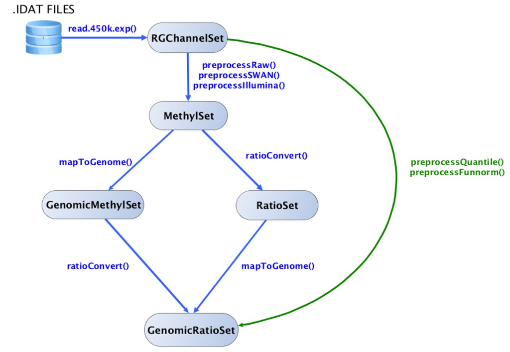

Classes diagram.

## 3.1 MethylSet and RatioSet objects

We have previously created the RGChannelSet object from the idats files, and now we have to convert it to a MethylSet object, that will only contain the methylated and unmethylated signals.

```r
MSet <- preprocessRaw(rgset)
MSet
```

```
## class: MethylSet
## dim: 866836 13
## metadata(0):
## assays(2): Meth Unmeth
## rownames(866836): cg18478105 cg09835024 ... cg10633746 cg12623625
## rowData names(0):
## colnames(13): GSM4105187_CD1 GSM4105188_CD2 ... GSM4105198_N5
##   GSM4105199_N6
## colData names(6): X title ... Basename filenames
## Annotation
##   array: IlluminaHumanMethylationEPIC
##   annotation: ilm10b4.hg19
## Preprocessing
##   Method: Raw (no normalization or bg correction)
##   minfi version: 1.44.0
##   Manifest version: 0.3.0
```

Then, the accessors *getMeth()* and *getUnmeth()* can be used to get the methylated and unmethylated intensities matrices per each probe and sample.

```r
Meth<-getMeth(MSet)
head(Meth)[,1:3]
```

```
##            GSM4105187_CD1 GSM4105188_CD2 GSM4105189_CD3
## cg18478105            215            199            160
## cg09835024           2031            734            303
## cg14361672           3092           4150           3430
## cg01763666           3870           4193           3371
## cg12950382            746            824            573
## cg02115394            534            563            595
```

```r
UnMeth<-getUnmeth(MSet)
head(UnMeth)[,1:3]
```

```
##            GSM4105187_CD1 GSM4105188_CD2 GSM4105189_CD3
## cg18478105           8170           8413           8841
## cg09835024           9905          10664           9195
## cg14361672           4899           4992           4515
## cg01763666            367            508            310
## cg12950382            171            215            257
## cg02115394           7492           7815           7854
```

To store the Beta values and/or M values instead of the methylated and unmethyalted signals, a RatioSet object is created:

```r
# --- Get BETA values ---
RSet <- ratioConvert(MSet, what = "both", keepCN = TRUE)
RSet #Data is not normalized yet.
```

```
## class: RatioSet
## dim: 866836 13
## metadata(0):
## assays(3): Beta M CN
## rownames(866836): cg18478105 cg09835024 ... cg10633746 cg12623625
## rowData names(0):
## colnames(13): GSM4105187_CD1 GSM4105188_CD2 ... GSM4105198_N5
##   GSM4105199_N6
## colData names(6): X title ... Basename filenames
## Annotation
##   array: IlluminaHumanMethylationEPIC
##   annotation: ilm10b4.hg19
## Preprocessing
##   Method: Raw (no normalization or bg correction)
##   minfi version: 1.44.0
##   Manifest version: 0.3.0
```

Now, we can get the beta values matrix:

```r
beta <- getBeta(RSet)
head(beta)[,1:3] #show the beta-values of the 6 first probes and 3 first samples
```

```
##            GSM4105187_CD1 GSM4105188_CD2 GSM4105189_CD3
## cg18478105     0.02564103     0.02310729     0.01777580
## cg09835024     0.17015751     0.06439726     0.03190145
## cg14361672     0.38693530     0.45394881     0.43171806
## cg01763666     0.91338211     0.89193789     0.91578375
## cg12950382     0.81352236     0.79307026     0.69036145
## cg02115394     0.06653377     0.06719981     0.07042254
```

For each sample and probe, we have a beta value, from 0 to 1, and they represent the proportion of how many cells had a methylated base. We would expect to get a 1 if we have a perfect methylated locus, or a 0, if it was perfectly unmethylated.

## 3.2 GenomicRatioSet

After obtaining a RatioSet object, we will use the function *mapToGenome()* to get the genomic coordinates to each probe and other information. The output will be an object (GenomicRatioSet) that will have the beta values with the coordinates of the genome.

```r
GRset <- mapToGenome(RSet)
beta<-getBeta(GRset)
GRset #Get the probe location to the genome
```

```
## class: GenomicRatioSet
## dim: 865859 13
## metadata(0):
## assays(3): Beta M CN
## rownames(865859): cg14817997 cg26928153 ... cg07587934 cg16855331
## rowData names(0):
## colnames(13): GSM4105187_CD1 GSM4105188_CD2 ... GSM4105198_N5
##   GSM4105199_N6
## colData names(6): X title ... Basename filenames
## Annotation
##   array: IlluminaHumanMethylationEPIC
##   annotation: ilm10b4.hg19
## Preprocessing
##   Method: Raw (no normalization or bg correction)
##   minfi version: 1.44.0
##   Manifest version: 0.3.0
```

To return the probe locations as a GenomicRanges objects, one can use the accessor granges:

```r
gr <- granges(GRset)
head(gr, n= 3)
```

```
## GRanges object with 3 ranges and 0 metadata columns:
##              seqnames    ranges strand
##                 <Rle> <IRanges>  <Rle>
##   cg14817997     chr1     10525      *
##   cg26928153     chr1     10848      *
##   cg16269199     chr1     10850      *
##   -------
##   seqinfo: 24 sequences from hg19 genome; no seqlengths
```

For each probe, we can assign its position to the genome. This ones, for example, are in chromosome 1, and the first one is in the position 10525 (single base-pair position).

# 4 BLOCK 1: QUALITY CONTROL

The aim of this step is to detect outliers in samples and probes and to remove them (if any). We will use the package *minfi*, that provides a quality control plot that calculates the log median intensity in the methylated and unmethylated channels.

So, for each sample, we will get the median of methylated and unmethylated:

```r
#The functions getQC and plotQC are designed to extract and plot the quality control information from the MethylSet:
qc <- getQC(MSet)
qc
```

```
## DataFrame with 13 rows and 2 columns
##                     mMed      uMed
##                <numeric> <numeric>
## GSM4105187_CD1  10.73725  10.76818
## GSM4105188_CD2  10.81218  10.90614
## GSM4105189_CD3  10.59246  10.64656
## GSM4105190_CD4  10.11114  10.34873
## GSM4105191_CD5   9.49586   9.72281
## ...                  ...       ...
## GSM4105195_N2   10.48281  10.59619
## GSM4105196_N3   10.48583  10.61930
## GSM4105197_N4   10.42626  10.42312
## GSM4105198_N5    9.96434   9.88874
## GSM4105199_N6    9.29232   9.33985
```

When plotting these two medians against each other, it has been observed that good samples will aggregate together, whereas bad sample will tend to be separated (far from the samples clustering), and will have lower median intensities.

Next, we can plot the median of of unmethylated versus the median of methylated for each sample.

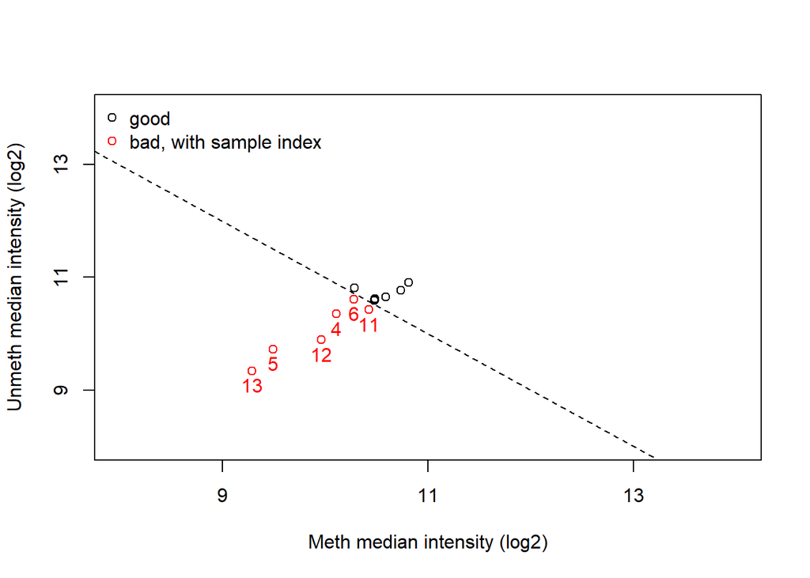

```r
plotQC(qc, badSampleCutoff = 10.5)#default
```

The cut off that will determine if a sample is good or bad, is set to 10.

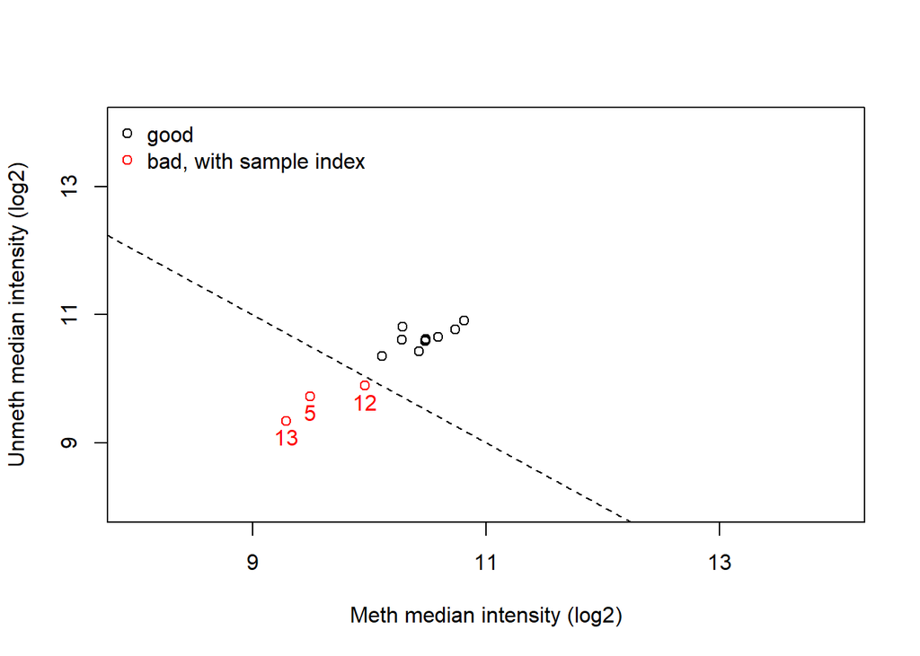

```r
plotQC(qc, badSampleCutoff = 10) #to change the cut off
```

If we use the default threshold, set to 10.5 (the first plot), we would see that the cut off is in the middle of the cluster of the samples, and the median intensity difference between some good samples and some bad samples (6 and 11) would be minimum. So, samples are so close that if one is well hybridized the other can not be as bad as to be rejected and therefore removed. That is why the cut off is set to 10.

10 samples will pass the first quality control. Therefore, we decide that 5, 12, and 13 samples will be removed.

```r
#samples to remove: 13,5,12
remove<-c(13,5,12)
rgset<-rgset[,-remove] #remove the samples previously selected, from the rgset object
targets = targets[-remove,] #remove the samples from the target data frame
#keep 10 samples
dim(rgset)
```

```
## [1] 1052641      10
```

```r
table(targets$patient.diagnosis.ch1)
```

```
##
##    Crohn's Disease No Crohn's Disease
##                  6                  4
```

We started with 7 samples of Crohn’s Disease patients and 6 healthy controls. After removing the bad quality samples, we end with 6 samples of Crohn’s Disease and 4 healthy controls.

To further explore the quality of the samples, it is useful to look at the Beta value densities of the samples, with the option to color the densities by Crohn’s Disease status:

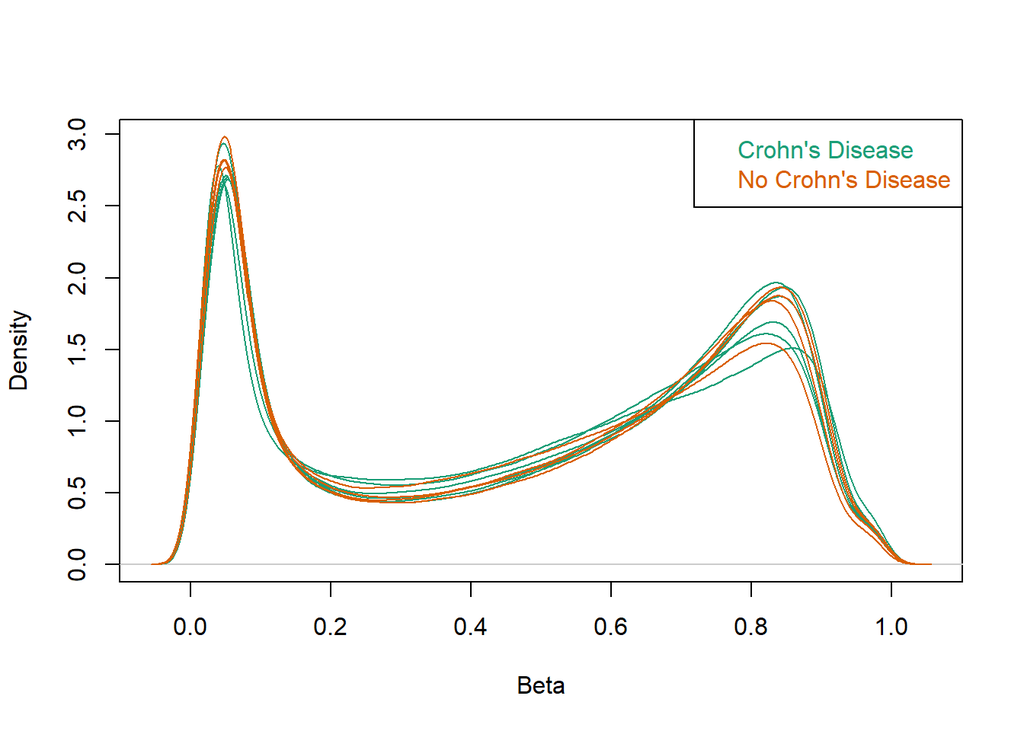

```r
densityPlot(MSet, sampGroups = targets$patient.diagnosis.ch1)
```

Each line of the plot represents a sample, and they are colored depending on their phenotype. We expect to see most beta values close to 0 or 1, indicating that most of the CpGs in the samples are unmethylated or methylated. In this case, samples have a good shape, as the peaks of beta values are close to 0 and close to 1.

Next, to perform the quality control of the probes, we will analyse the detection p-values for every CpG. Each probe has an specific detection p-value, a measure of how likely it is that a given signal is background fluorescense, so it will be used to identify/know if the probe is well hybridized or not.

```r
detP<-detectionP(rgset)
dim(detP) #all the probes we have in the EPIC array
```

```
## [1] 866836     10
```

```r
head(detP)[,1:3] #colums are samples and probes are rows
```

```
##            GSM4105187_CD1 GSM4105188_CD2 GSM4105189_CD3
## cg18478105   0.000000e+00   0.000000e+00   0.000000e+00
## cg09835024   0.000000e+00   0.000000e+00   0.000000e+00
## cg14361672   0.000000e+00   0.000000e+00   0.000000e+00
## cg01763666   0.000000e+00   0.000000e+00   0.000000e+00
## cg12950382   5.237227e-24   7.888816e-17   6.378934e-10
## cg02115394   0.000000e+00   0.000000e+00   0.000000e+00
```

To properly visualize if samples have probes that are not well hybridized, we will generate a plot. The mean detection p-value for each sample will be plotted, and if a sample has a large mean detection p-value, that exceeds an specific cut off, it will be removed from the analysis.

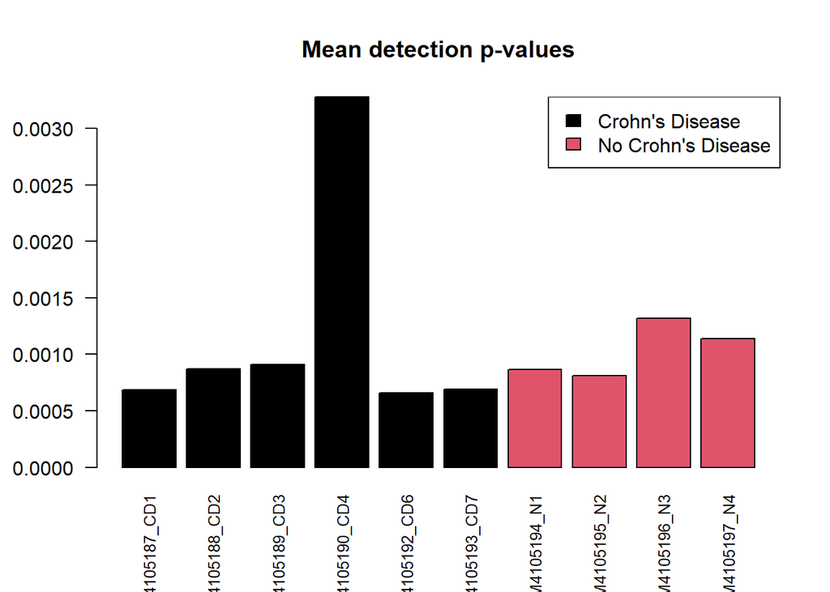

```r
barplot(colMeans(detP),col=factor(targets$patient.diagnosis.ch1),las=2,cex.names=0.8,
        main="Mean detection p-values")


# Add a legend to the plot by indicating the color of each diagnosis group.
legend("topright", legend = levels(factor(targets$patient.diagnosis.ch1)), fill = unique(factor(targets$patient.diagnosis.ch1)))
```

Important to note that we are plotting the mean of the detection p-value of each sample.

There are a few methods for calculating these detection p-values, depending on the package we are using. In this case, we use the **minfi** package for the methylation analysis, and when using this package it is highly recommended to use an stringent exclusion criteria of p-values > 0.01 being excluded. Minfi uses a method based on the comparison of the total signal(M+U) for each probe to the background singal level, which is estimated from the negative control probes. Small p-values are indicative of a reliable signal whilst large p-values will indicate a poor quality signal.

So, the threshold that will determine if we include or exclude a sample is 0.01. The samples that have a mean detection p-values over 0.01 will be removed, because it will contain so many failed probes. In this case, the mean of the detection p-values for each sample is under the threshold. It doesn’t mean that all the probes are well hybridized, we can have a probe that its detection p-value is higher than the threshold, but the average of all the probes for the sample is under the threshold, so we do not remove it, because that means that mainly all the probes of the sample are well hybridized (but not necessarily all of them).

This bar plot only includes the samples that previously passed the quality control.

```r
## No samples exceed the cutoff of 0.01, so now no samples are going to be removed.
keep<-colMeans(detP) < 0.01
table(keep)
```

```
## keep
## TRUE
##   10
```

We will continue the analysis will all the 10 samples.

In the other hand, we can have a failed prove for each of the samples. If the row mean of the detection p-value for a probe is higher than the threshold, it means that the probe has high p-values in all the samples, hence the probe is not well hybridized and has to be removed.

```r
keep<-rowMeans(detP) < 0.01
table(keep)
```

```
## keep
##  FALSE   TRUE
##  11054 855782
```

11054 probes are removed, and 855782 probes will pass the quality control.

```r
#keep with the well hibrizided probes in the row of the rgset
rgset<-rgset[keep,]
```

## 4.1 Sex predicion of the samples

In the sample sheet we don’t have the sex information, and may be interested to predict it. As we have removed probes and samples, we create again the MethylSet, RSet and GRset objects:

```r
MSet <- preprocessRaw(rgset)
RSet <- ratioConvert(MSet, what = "both", keepCN = TRUE)
GRset <- mapToGenome(RSet)
```

If we look at the median total intensity of the X chromosome-mapped probes, denoted med(X)med(X), and the median total intensity of the Y-chromosome-mapped probes, denoted med(Y)med(Y), one can observe two different clusters of points corresponding to the gender of the samples. To predict the gender, minfi separates the points by using a cutoff on log2med(Y). Since the algorithm needs to map probes to the X-chr and to the Y-chr, the input of the function getSex needs to be a GenomicMethylSet or a GenomicRatioSet.

```r
predictedSex <- getSex(GRset, cutoff = -2)
predictedSex
```

```
## DataFrame with 10 rows and 3 columns
##                     xMed      yMed predictedSex
##                <numeric> <numeric>  <character>
## GSM4105187_CD1   12.2506   8.29462            F
## GSM4105188_CD2   12.3720   8.56033            F
## GSM4105189_CD3   11.3971  11.99979            M
## GSM4105190_CD4   11.7932   8.63118            F
## GSM4105192_CD6   11.1699  11.75843            M
## GSM4105193_CD7   11.2378  11.74672            M
## GSM4105194_N1    12.0526   8.22641            F
## GSM4105195_N2    11.3049  11.88736            M
## GSM4105196_N3    12.0875   8.53528            F
## GSM4105197_N4    11.9715   8.43879            F
```

For each sample, we have added a new column which indicates the gender. To visuallize the results, we can create a plot:

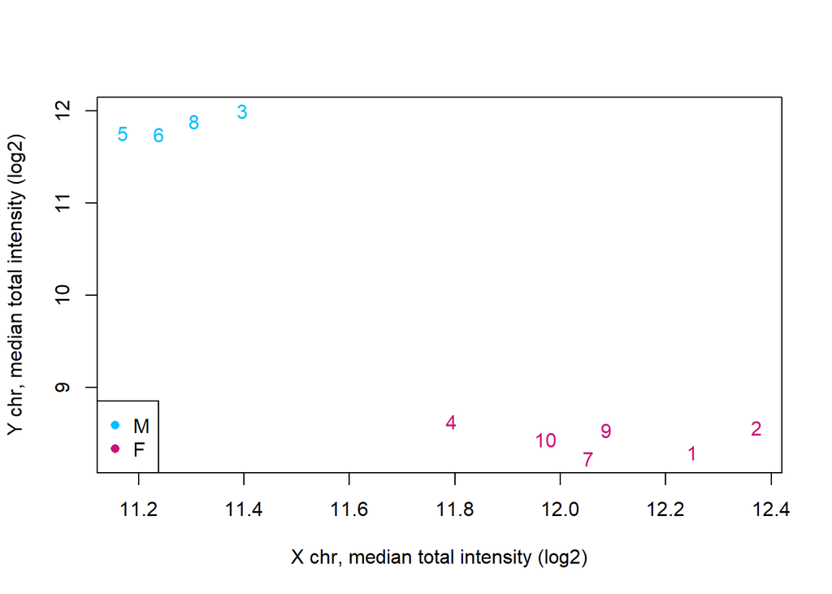

```r
# ---- plot ----
GRset<-addSex(GRset) #add sex to GRatio object
plotSex(GRset)
```

Samples 3, 5, 6, and 8 correspond to males, and 1, 2, 4, 7, 9 and 10 correspond to females.

# 5 BLOCK 2: ANALYSIS

## 5.1 Normalization

Until now, no normalization was used to process the data (we had raw data). As we do not expect global differences between the samples, we will use the **preprocessQuantile()** function, that will implement a stratified quantile normalization. The input of this function is a RGChannelSet and it returns a GenomicRatioSet object.

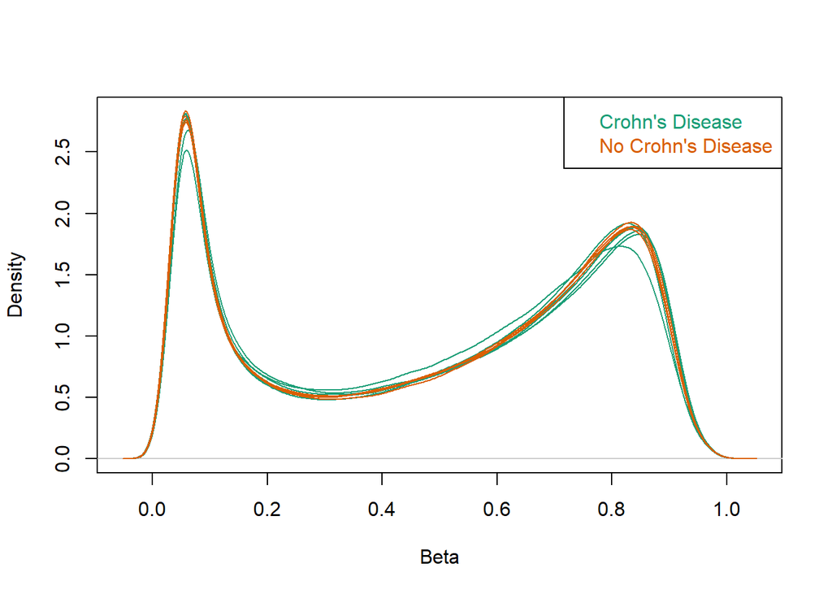

```r
# --- Normalization ---
gRatioSet.quantile <- preprocessQuantile(rgset,verbose = T)

#PLOT
densityPlot(getBeta(gRatioSet.quantile), sampGroups = targets$patient.diagnosis.ch1)
```

If we compare the distribution of beta values before and after normalization, we will not see huge differences, but slightly.

## 5.2 Remove certain CpGs

As this is a disease versus healthy control study, we are not interested in the CpGs probes that are located in the sexual chromosomes, and will be removed. This is because methylations in these chromosomes are very variable and come from imprinting, for example, or other aspects, which are not important for the analysis.

```r
 # --- Get the Annotation ---
ann850k<-getAnnotation(IlluminaHumanMethylationEPICanno.ilm10b4.hg19)
head(ann850k)[,1:25] #show only 25 first columns information
```

```
## DataFrame with 6 rows and 25 columns
##                    chr       pos      strand        Name    AddressA
##            <character> <integer> <character> <character> <character>
## cg18478105       chr20  61847650           -  cg18478105    46761277
## cg09835024        chrX  24072640           -  cg09835024    16745152
## cg14361672        chr9 131463936           +  cg14361672    51800947
## cg01763666       chr17  80159506           +  cg01763666    37768834
## cg12950382       chr14 105176736           +  cg12950382     8726444
## cg02115394       chr13 115000168           +  cg02115394    68602543
##               AddressB              ProbeSeqA              ProbeSeqB
##            <character>            <character>            <character>
## cg18478105    86644198 AAATAAATTTCACTCTCAAA.. AAATAAATTTCGCTCTCAAA..
## cg09835024    81631976 AATAAACACCAACCCCAAAC.. AATAAACGCCGACCCCGAAC..
## cg14361672     7743487 ATCACTACCTAATCTATAAC.. ATCACTACCTAATCTATAAC..
## cg01763666    23754592 AAACAAAAATAAACAAACTC.. GAACAAAAATAAACGAACTC..
## cg12950382    76660327 ATACCAAAAAATAACAATAT.. GTACCGAAAAATAACAATAT..
## cg02115394    59659581 AAAATCACTACAACACCTCT.. AAAATCGCTACGACGCCTCT..
##                   Type    NextBase       Color    Probe_rs Probe_maf
##            <character> <character> <character> <character> <numeric>
## cg18478105           I           C         Grn          NA        NA
## cg09835024           I           A         Red          NA        NA
## cg14361672           I           T         Red          NA        NA
## cg01763666           I           C         Grn          NA        NA
## cg12950382           I           A         Red  rs12882277  0.378464
## cg02115394           I           A         Red          NA        NA
##                 CpG_rs   CpG_maf      SBE_rs   SBE_maf           Islands_Name
##            <character> <numeric> <character> <numeric>            <character>
## cg18478105          NA        NA          NA        NA chr20:61846843-61848..
## cg09835024          NA        NA          NA        NA chrX:24072558-24073135
## cg14361672          NA        NA          NA        NA chr9:131464843-13146..
## cg01763666          NA        NA          NA        NA
## cg12950382          NA        NA          NA        NA
## cg02115394          NA        NA          NA        NA chr13:115000148-1150..
##            Relation_to_Island       Forward_Sequence              SourceSeq
##                   <character>            <character>            <character>
## cg18478105             Island TCCCGTCTTACGGGATGGAT.. CGGTCCCCGCCCCGCCGCAC..
## cg09835024             Island AGCCCCGTCATAGGTGGGCG.. GGTGGGCGCCGACCCCGAGC..
## cg14361672            N_Shore TCACCTTCCCACCTCCTGGA.. CGCAGGATGCCAGGACGGGC..
## cg01763666            OpenSea CTGGAATGCCAGCTGCTGCT.. CGCCTGCCTCAGCTTAGCTG..
## cg12950382            OpenSea CCCTGCTGCCACCACCTCGG.. CGCCACTCGGGCACGTGCAC..
## cg02115394             Island TTCTGGGGAAAGAAGGCTCA.. GGAATCGCTGCGGCGCCTCT..
##            UCSC_RefGene_Name UCSC_RefGene_Accession UCSC_RefGene_Group
##                  <character>            <character>        <character>
## cg18478105            YTHDF1              NM_017798             TSS200
## cg09835024            EIF2S3              NM_001415            TSS1500
## cg14361672              PKN3              NM_013355            TSS1500
## cg01763666            CCDC57              NM_198082               Body
## cg12950382         INF2;INF2 NM_022489;NM_001031714          Body;Body
## cg02115394       CDC16;CDC16 NM_003903;NM_001078645      TSS200;TSS200
##            Phantom4_Enhancers
##                   <character>
## cg18478105
## cg09835024
## cg14361672
## cg01763666
## cg12950382
## cg02115394
```

```r
ann850k<-as.data.frame(ann850k)
```

For each probe name, there is information regarding the chromosome in which it is located, the genomic position, the probe seq, type of probe, the gene that is mapping to, the relation to island… and others. Important to note that one probe can map to several positions (2 different genes or 2 different isoforms).

From the normalized object, remove those CpG that are in the sexual chromosomes:

```r
#The featureNames of the object are the probes. Then, get the probes that are not (!) in the sexual chromosomes in the annotation
keep <- !(featureNames(gRatioSet.quantile) %in% ann850k$Name[ann850k$chr %in% c("chrX","chrY")])
table(keep) #nearly 20000 probes are located in the chr X and Y
```

```
## keep
##  FALSE   TRUE
##  19363 834726
```

```r
gRatioSet.quantile <- gRatioSet.quantile[keep,] #get in the genomic ratioSet normalized object, the probes previously selected.
```

We have 19363 probes in the array that are located in the sexual chromosomes, and are removed.

Moreover, there can be SNPs inside the probes that can have important consequences on the analysis, and as they are very variable between individuals, we will remove all those probes that contain SNPs at the CpGs. As it is known, Cytosine to Thymine (C-T) substitutions are the most common type of SNPs in the genome and in a DNA-methylation analysis, the bisulfite treatment is used in the laboratory to convert the unmethylated cytosines to uracil. This makes that C-T SNPs can interfere with the methylation analysis, because it may cause that a cytosine truly methylated appears as unmethylated, and vice versa. This inaccurate estimation of the methylation levels will impact the interpretation of the results. That is the reason why the probes with SNPs should be removed in the analysis.

The package minfi has a special function to remove such probes. First apply the function getSnPInfo to the GenomicRatioSet object previously created, and will return a data frame containing SNP information of the probes:

```r
# --- get SNP information ---
snp.info<-getSnpInfo(gRatioSet.quantile)
snp.info[10:20,]
```

```
## DataFrame with 11 rows and 6 columns
##               Probe_rs Probe_maf      CpG_rs   CpG_maf      SBE_rs   SBE_maf
##            <character> <numeric> <character> <numeric> <character> <numeric>
## cg21870274          NA        NA          NA        NA          NA        NA
## cg03130891  rs77418980  0.305556          NA        NA          NA        NA
## cg04098293          NA        NA          NA        NA          NA        NA
## cg16382250          NA        NA          NA        NA          NA        NA
## cg24335620 rs147502335  0.012800          NA        NA          NA        NA
## cg22463138 rs187450123  0.024700          NA        NA          NA        NA
## cg16162899          NA        NA          NA        NA          NA        NA
## cg01803908 rs144425991  0.052200          NA        NA          NA        NA
## cg17149495          NA        NA          NA        NA          NA        NA
## cg22802167          NA        NA          NA        NA          NA        NA
## cg24669183   rs6680725  0.108100          NA        NA          NA        NA
```

Probe, CpG and SBE correspond to the SNPs that are inside the body of the probe, at the CpG and at the single nucleotide extension, respectively. Then, the columns ended with _rs, will give the name of the SNPs, and the columns ended with _maf, will give the minor allele frequency of the SNPS.

Then, the following function will allows to remove the probes that contain SNPs.

```r
gRatioSet.quantile<- dropLociWithSnps(gRatioSet.quantile)
dim(gRatioSet.quantile)
```

```
## [1] 804995     10
```

Keep with 804995 probes.

Now we can get the beta values to proceed with the downstream analysis.

```r
# --- Betas values (normalized) ---
betas<-getBeta(gRatioSet.quantile)
head(betas)[,1:2]
```

```
##            GSM4105187_CD1 GSM4105188_CD2
## cg14817997      0.7679702      0.7384376
## cg26928153      0.7764815      0.7900374
## cg16269199      0.6991262      0.6512504
## cg13869341      0.8784887      0.8421753
## cg14008030      0.6235429      0.6038882
## cg12045430      0.2091585      0.1937684
```

It is important to check that the column names of betas (samples) are in the same order than the targets basename

```r
# --- Same sample order ---
targets$Basename<-sub("_2011.*", "", colnames(rgset))
identical(colnames(betas),targets$Basename)
```

```
## [1] TRUE
```

```r
colnames(betas)
```

```
##  [1] "GSM4105187_CD1" "GSM4105188_CD2" "GSM4105189_CD3" "GSM4105190_CD4"
##  [5] "GSM4105192_CD6" "GSM4105193_CD7" "GSM4105194_N1"  "GSM4105195_N2"
##  [9] "GSM4105196_N3"  "GSM4105197_N4"
```

```r
targets$Basename
```

```
##  [1] "GSM4105187_CD1" "GSM4105188_CD2" "GSM4105189_CD3" "GSM4105190_CD4"
##  [5] "GSM4105192_CD6" "GSM4105193_CD7" "GSM4105194_N1"  "GSM4105195_N2"
##  [9] "GSM4105196_N3"  "GSM4105197_N4"
```

## 5.3 DMPs without covariates

In this step, we are going to identify which are the CpG sites that are differentially methylated between the different conditions (crohn’s disease versus healthy).

As M-values have nicer distributional properties than beta-values, they are more statistically valid for the differential analysis of methylation, obtaining t-statistics and their respective p-values for each CpG. In the other hand, Beta values will be used for the graphical representation of the methylation levels, as representing percentages has a more intuitive biological interpretation.

Those probes with a p-value under 0.05 will be differentially methylated between the crohn’s disease and the healthy samples of the patients, thus, will be selected for the analysis.

```r
library(limma) #used to build a linear model

# --- Design a matrix ---
group<-as.factor(pData(gRatioSet.quantile)$patient.diagnosis.ch1)
design <- model.matrix(~group)
colnames(design)<-c("Intercept","Group")

# --- Get M-values ---
Mvalues<-logit2(betas)

# --- Generate adjusted matrix ---
fit <- lmFit(Mvalues, design)

fit2 <- eBayes(fit)

# --- Get results ---
results <- topTable(fit2,coef="Group",num=dim(fit2)[1],sort.by="P",adjust.method = "BH")
head(results)
```

```
##                logFC     AveExpr          t      P.Value adj.P.Val        B
## cg11942594 -1.959003  0.01015343 -10.242962 1.394023e-07 0.1122181 4.511461
## cg07005654 -1.982254 -2.15218400  -9.126360 5.249640e-07 0.2035935 3.910235
## cg17541002 -2.335837 -0.18207878  -8.833341 7.587382e-07 0.2035935 3.730962
## cg18692149  3.232940 -1.98242202   8.163993 1.822093e-06 0.3541982 3.283032
## cg06400318  1.614187  1.99376486   8.000003 2.275827e-06 0.3541982 3.164534
## cg27569300  1.263500 -2.80877962   7.835070 2.855273e-06 0.3541982 3.041659
```

```r
#Subset the results that have a p-value under 0.05
dmp_all<-subset(results,results$P.Value<.05)
dim(dmp_all)
```

```
## [1] 66285     6
```

From 804995 probes, only 66285 are differentially methylated (DM) between crohn and healthy patients. As we want to know in which regions they are located, we need to merge the resulting data.frame containing the DM probes with the annotation (by rows). As a result, we will obtain the gene name the probe is matching to, the relation to island, and the position where each CpG is located, to know if it is in the promoter region or not.

```r
# --- Merge the DM probes with the annotation ---
dmp_all <- merge(dmp_all,ann850k[,c("UCSC_RefGene_Name","Relation_to_Island","UCSC_RefGene_Group")], by="row.names")
rownames(dmp_all)<-dmp_all$Row.names
dmp_all<-dmp_all[,-1]#remove the column Row.names, as we already have the probes in the rows
head(dmp_all)
```

```
##                 logFC    AveExpr         t    P.Value adj.P.Val         B
## cg00000221 -0.4958653  1.4694971 -2.592300 0.02236903 0.5487249 -3.151120
## cg00000236 -0.4151967  1.3414441 -2.629474 0.02084617 0.5443735 -3.096373
## cg00000289 -0.6428395  1.3096771 -2.484118 0.02743972 0.5626218 -3.309584
## cg00000363 -0.4340195 -3.0716475 -2.930918 0.01172100 0.5159913 -2.648921
## cg00000579 -0.5310100  2.7326719 -2.261588 0.04155987 0.5918562 -3.630155
## cg00000924 -0.3598977  0.5040562 -2.383401 0.03314342 0.5748243 -3.455707
##               UCSC_RefGene_Name Relation_to_Island UCSC_RefGene_Group
## cg00000221               ANKFN1            OpenSea               Body
## cg00000236          VDAC3;VDAC3            OpenSea        3'UTR;3'UTR
## cg00000289    ACTN1;ACTN1;ACTN1            N_Shore  3'UTR;3'UTR;3'UTR
## cg00000363                                 N_Shore
## cg00000579               GABBR2            OpenSea               Body
## cg00000924 KCNQ1;KCNQ1OT1;KCNQ1             Island     Body;Body;Body
```

We obtained a huge number of DM positions, that correspond to all the CpG sites of the whole genome. But in fact, we are only interested in those CpGs that are located in the promoter, and promoter plus island, as it is known that methylation in promoters is related to the regulation of the expression of a gene: high methylation - low expression ; low methylation - High expression.

For this reason, we will get all the CpGs that are located in TSS1500, TSS200, 5’UTR or 1st Exon of the gene, which correspond to the promoter region.

```r
# --- Get CpG probes that are in the promoter ---
proms<-dmp_all[grep("TSS1500|TSS200|5'UTR|1stExon",dmp_all$UCSC_RefGene_Group),]
dim(proms)
```

```
## [1] 18489     9
```

From 66285 DMP, 18489 are in promoter regions. Moreover, we are also interested to know which of them are in the island.

```r
# --- Get the DMp that are in promoter+island ---
proms.island<-proms[proms$Relation_to_Island=="Island",]
dim(proms.island)
```

```
## [1] 5197    9
```

```r
head(proms.island)
```

```
##                 logFC   AveExpr         t    P.Value adj.P.Val         B
## cg00005543  0.8762283 -4.847276  3.342947 0.00530973 0.4846929 -2.035912
## cg00010168 -0.4717841 -2.901377 -2.264125 0.04136558 0.5915106 -3.626551
## cg00012992  0.5497850 -3.532855  2.722720 0.01745706 0.5367402 -2.958517
## cg00014986  0.8434066 -3.469489  2.733449 0.01710350 0.5354311 -2.942615
## cg00016066  0.9823444 -4.331404  2.446486 0.02945082 0.5670184 -3.364358
## cg00023154  0.3763085 -3.267512  2.308155 0.03812719 0.5845331 -3.563795
##                                                                        UCSC_RefGene_Name
## cg00005543                                                           TCTE3;C6orf70;TCTE3
## cg00010168                                                                   MMS19;UBTD1
## cg00012992                                                                         PRKCH
## cg00014986 ANAPC11;ANAPC11;ANAPC11;ANAPC11;ANAPC11;ANAPC11;ANAPC11;ANAPC11;ANAPC11;THOC4
## cg00016066                                             TCF12;LOC145783;TCF12;TCF12;TCF12
## cg00023154                                                                        RNF220
##            Relation_to_Island
## cg00005543             Island
## cg00010168             Island
## cg00012992             Island
## cg00014986             Island
## cg00016066             Island
## cg00023154             Island
##                                                            UCSC_RefGene_Group
## cg00005543                                               5'UTR;TSS200;1stExon
## cg00010168                                                     TSS1500;TSS200
## cg00012992                                                             TSS200
## cg00014986 5'UTR;5'UTR;5'UTR;5'UTR;5'UTR;5'UTR;1stExon;TSS200;1stExon;TSS1500
## cg00016066                                   TSS200;Body;TSS200;TSS200;TSS200
## cg00023154                                                              5'UTR
```

5197 differentially methylated CpG positions are in the promoter islands of the genes.

To test visually if this DM positions can separate the two types of samples, crohn disease in one site and healthy in the other site, first we have to distinguish between the two type of samples, and create a code for colors. Those that have ‘CD’ in their name are crohn’s disease samples, and if they have an ‘N’, are healthy samples.

```r
Healthy <- grep("N",colnames(betas),perl=T)
Crohn <- grep("CD",colnames(betas),perl=T)
spcol <- c(rep("red",length(Crohn)),rep("blue1",length(Healthy)))
library(gplots)
```

For a proper visualization we will be even more stringent and the CpG DM in the promoter + island will be subseted by LogFC, which is the change in the average of M-values between conditions. So, those probes that have a larger or smaller logFC value, will be stronger differentially methylated, and this are plotted.

Once the most DM CpGs are selected, the beta values of this probes are extracted (as beta values are preferable to visualize).

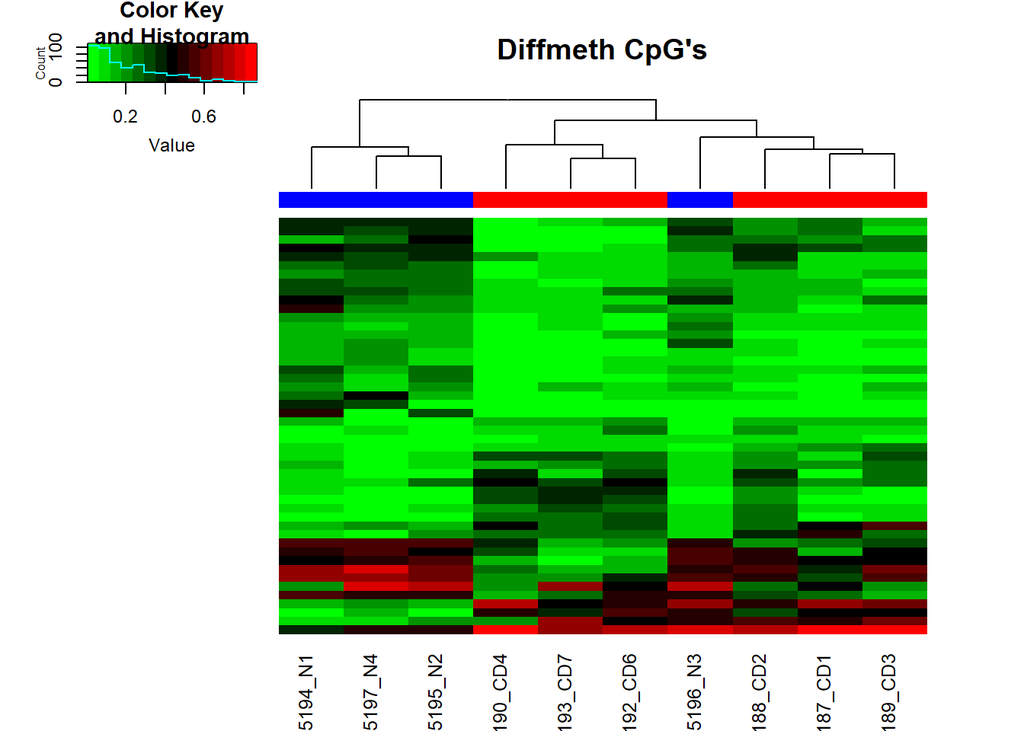

```r
# Subset by logFC (for visualize properly)
proms.island_sub<-proms.island[proms.island$logFC>1.5 | proms.island$logFC<  -1.5, ]

# --- Heatmap ---
#We want a matrix of those CpG in betas and those that are in proms.islands results, and first all the crohn and then all the healthy
l <- as.matrix(betas[rownames(betas) %in% rownames(proms.island_sub),c(Crohn,Healthy)])
heatmap.2(l,
          main="Diffmeth CpG's",
          labRow=NA,
          trace="none",
          na.rm=T,
          col=greenred,
          ColSideColors=spcol,
          distfun=function(x) dist(x,method="euclidean"),
          dendrogram = "column")
```

In this heatmap we can see that there is a healthy sample that aggregates with the crohn’s disease sample for this CpG probes that we are representing. The first set of CpGs are higher expressed in healthy samples than in crohn’s. Then the second block of CpGs is low methylated in healthy and more methylated in crhon’s samples. The third set of CpG probes is hypermethylated in healthy samples, and in general, lower in crohn’s. Finally, the last block is hypomethylated in healthy and hypermethylated in crohn’s disease adipose samples.

Then, a PCA is performed to see how samples are split.

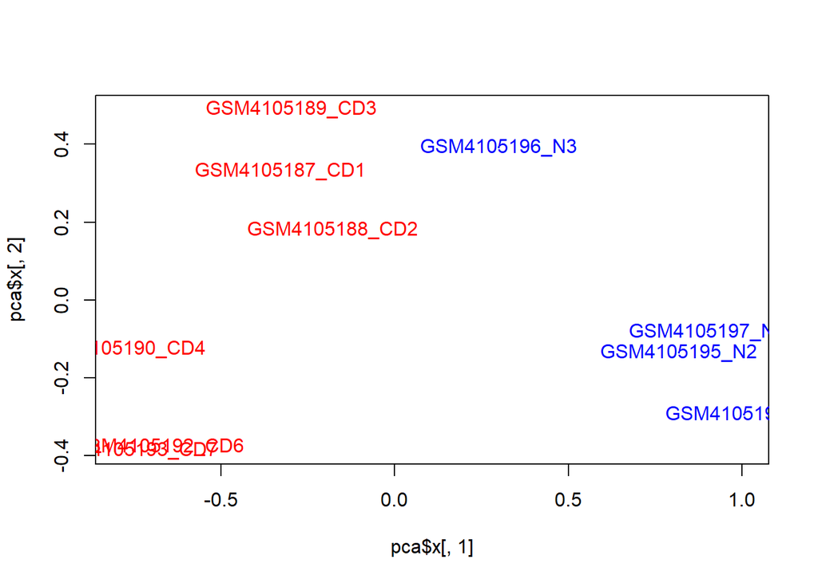

```
## integer(0)
```

```r
# ---PCA---
pca <- prcomp(t(na.omit(l)))
plot(pca$x[,1],pca$x[,2],col=spcol,cex=.2)+text(pca$x[,1],pca$x[,2],labels=rownames(pca$x),col=spcol,cex=1)
```

In the PCA plot it is seen that samples, in general, are well splitted. Crohn’s samples stay at one side (aggregate together) and healthy samples at the other, except just one of them (N3), that stays more in the middle.

## 5.4 DMPs with sex

Now, we will identify the differentially methylated CpG but considering the variable sex, which has been previously predicted. For that, a matrix is designed using *limma*.

Then, using the *topTable()* function of limma package, the differentially methylated CpG probes will be extracted. These results are ordered by p-value.

```r
# --- Design a matrix ---
group<-as.factor(pData(gRatioSet.quantile)$patient.diagnosis.ch1) #0 --Crohn Disease; 1-- Healthy
design <- model.matrix(~group+pData(gRatioSet.quantile)$predictedSex) #0--Female; 1--Male
colnames(design)<-c("Intercept","Group","Gender")
head(design)
```

```
##   Intercept Group Gender
## 1         1     0      0
## 2         1     0      0
## 3         1     0      1
## 4         1     0      0
## 5         1     0      1
## 6         1     0      1
```

```r
# --- Get M-values --- (as they are better for the statistical analysis)
Mvalues<-logit2(betas)

# --- Fit the model ---
fit <- lmFit(Mvalues, design)

fit2 <- eBayes(fit)

#get the table of results
results <- topTable(fit2,coef="Group",num=dim(fit2)[1],sort.by="P",adjust.method = "BH") ####Pval list 1
head(results)
```

```
##                logFC     AveExpr         t      P.Value adj.P.Val        B
## cg11942594 -1.955085  0.01015343 -9.514782 6.142421e-07 0.4944618 2.515853
## cg07005654 -2.009924 -2.15218400 -8.694371 1.594607e-06 0.5351172 2.175779
## cg17541002 -2.244476 -0.18207878 -8.510064 1.994238e-06 0.5351172 2.090922
## cg26281470 -1.651688 -0.28726092 -7.950825 4.019948e-06 0.6116386 1.811971
## cg18692149  3.195378 -1.98242202  7.552334 6.769467e-06 0.6116386 1.591671
## cg01642049  1.268079 -5.64868252  7.437937 7.889345e-06 0.6116386 1.524841
```

Those probes with a p-value under 0.05 will be differentially methylated between the crohn’s disease and the healthy samples of the patients.

```r
# --- Subset results by p-value ---
dmp_all_sex<-subset(results,results$P.Value<.05)
dim(dmp_all_sex)
```

```
## [1] 57135     6
```

From the 804995 probes that enter the analysis, 57135 are found to be significant differentially methylated between crhon and healthy patients.

Next, the resulting data.frame containing the DM CpG sites will be merged with the annotation (by rows), to get the gene name, relation to island, and the position where the CpG is located, with the aim to know if it is in the promoter or not.

```r
# --- Merge the DM probes with the annotation ---
dmp_all_sex <- merge(dmp_all_sex,ann850k[,c("UCSC_RefGene_Name","Relation_to_Island","UCSC_RefGene_Group")], by="row.names")
dmp_all_sex<-as.data.frame(dmp_all_sex) #create a data frame
rownames(dmp_all_sex)<-dmp_all_sex$Row.names #Specify that the column named Row.names is the row
dmp_all_sex<-dmp_all_sex[,-1] #remove the column Row.names, as we already have the probes in the rows
head(dmp_all_sex)
```

```
##                 logFC    AveExpr         t    P.Value adj.P.Val         B
## cg00000221 -0.4809965  1.4694971 -2.348129 0.03684934 0.6859528 -3.514611
## cg00000236 -0.4040989  1.3414441 -2.387440 0.03430617 0.6828971 -3.464568
## cg00000289 -0.5096457  1.3096771 -2.200989 0.04806427 0.7018800 -3.700283
## cg00000363 -0.4103454 -3.0716475 -2.616191 0.02255220 0.6666459 -3.170982
## cg00000579 -0.5889566  2.7326719 -2.421535 0.03223800 0.6797774 -3.421044
## cg00001249  0.4513979  0.2595123  2.622469 0.02229256 0.6666385 -3.162885
##            UCSC_RefGene_Name Relation_to_Island UCSC_RefGene_Group
## cg00000221            ANKFN1            OpenSea               Body
## cg00000236       VDAC3;VDAC3            OpenSea        3'UTR;3'UTR
## cg00000289 ACTN1;ACTN1;ACTN1            N_Shore  3'UTR;3'UTR;3'UTR
## cg00000363                              N_Shore
## cg00000579            GABBR2            OpenSea               Body
## cg00001249                              S_Shelf
```

We obtained a huge number of DMP, that correspond to all the CpG sites of the whole genome. But in fact, we are only interested in those CpGs that are located in the promoter, and promoter plus island, as it is known that methylation in promoters is related to the regulation of the expression of a gene: high methylation -low expression ; low methylation - High expression.

For this reason, we will get all the CpGs that are located in TSS1500, TSS200, 5’UTR or 1st Exon of the gene, which correspond to the promoter region.

```r
# --- Get CpG probes that are in the promoter ---
proms_sex<-dmp_all_sex[grep("TSS1500|TSS200|5'UTR|1stExon",dmp_all_sex$UCSC_RefGene_Group),]
dim(proms_sex)
```

```
## [1] 16696     9
```

From the 57135 differentially methylated CpG positions, 16696 are found to be located in the promoter regions. Moreover we are also interested to know which of them are in the island.

```r
proms.island_sex<-proms_sex[proms_sex$Relation_to_Island=="Island",]
dim(proms.island_sex)
```

```
## [1] 5328    9
```

5328 DM CpG positions are in the promoter plus island.

For a proper visualization we will be even more stringent and the CpG DM in the promoter + island will be subseted by LogFC, which is the change in the average of M-values between conditions. So, those probes that have a larger or smaller logFC value, will be stronger differentially methylated, and this are plotted.

Then, the beta values of this probes are extracted (as beta values are preferable to visualize).

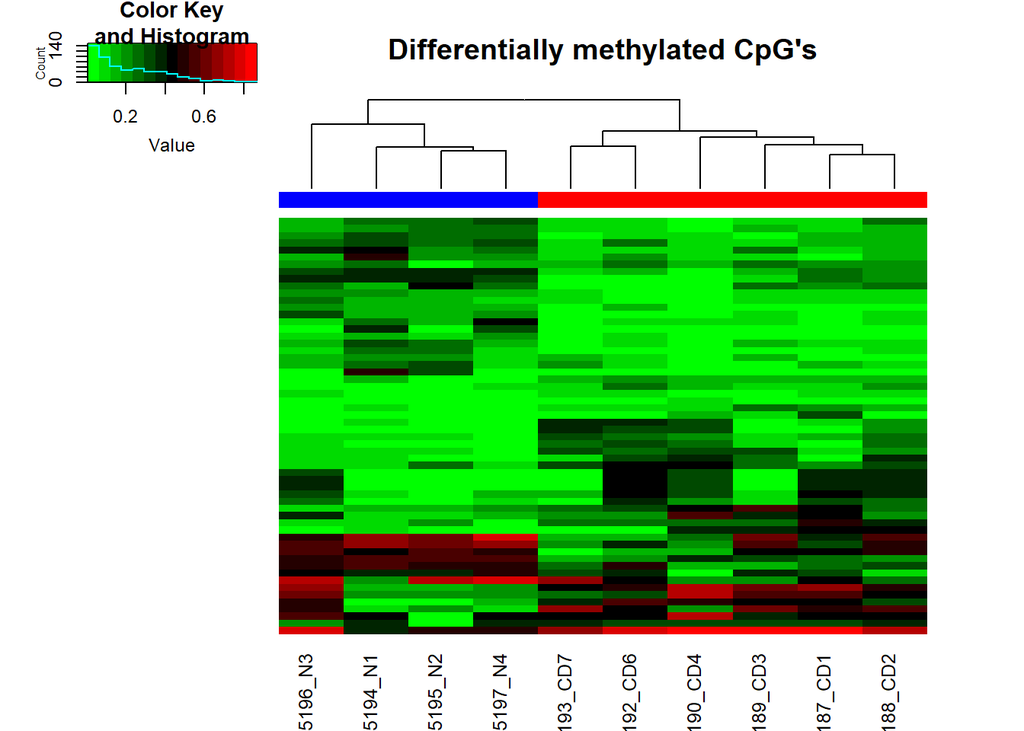

```r
# --- Subset by logFC ---
proms.island_sex_sub<-proms.island_sex[proms.island_sex$logFC>1.5 | proms.island_sex$logFC<  -1.5, ]

# --- Create a vector of colors depending on the condition ---
Healthy <- grep("N",colnames(betas),perl=T)
Crohn <- grep("CD",colnames(betas),perl=T)
spcol <- c(rep("red",length(Crohn)),rep("blue1",length(Healthy)))

library(gplots)
# --- get the beta values ---
l <- as.matrix(betas[rownames(betas) %in% rownames(proms.island_sex_sub),c(Crohn,Healthy)])

# --- Heatmap ---
heatmap.2(l,
          main="Differentially methylated CpG's",
          labRow=NA,
          trace="none",
          na.rm=T,
          col=greenred,
          ColSideColors=spcol,
          distfun=function(x) dist(x,method="euclidean"),
          dendrogram = "column")
```

The healthy adipose samples aggregate together in one side, and the crhon’s disease samples aggregate in the other side of the heatmap, which means that both conditions have a differentially methylated CpG pattern. The first set of CpGs are very low methylated in crohn and more methylated in healthy samples. Then there is a second set of CpGs that are low methylated in healthy samples, and higher methylated in crohn’s samples. We can distinguish a third block of CpG probes that are highly methylated in healthy samples and lower in crohn’s. Finally the last block of CpG is in general low methylated in healthy (except the first healthy sample), and higher methylated in crohn’s disease samples.

With the following PCA we can see how well the different type of samples are spitted.

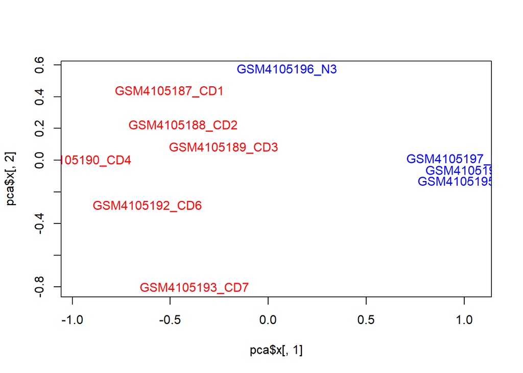

```r
# --- PCA ---
pca <- prcomp(t(na.omit(l)))
plot(pca$x[,1],pca$x[,2],col=spcol,cex=.2)
text(pca$x[,1],pca$x[,2],labels=rownames(pca$x),col=spcol,cex=1)
```

In general samples are very well splitted. Crhon’s samples stay at one side, and healthy samples at the other, except just one of them (N3), that stays more in the middle.

Note that differential methylation of the individual CpG sites may not be as informative (and it is hard to detect) as knowing the differntially methylated CpG regions. A more appropriate way to proceed should be using bumphunter to detect DM CpG regions (instead of single positions).

# 6 BLOCK 3

After performing the differential methylation analysis, we have obtained a long list of significantly differentially methylated CpG sites that have to be interpreted. In this block, we will try to identify which biological pathways are over represented in those differentially methylated CpGs by performing a typical gene ontology enrichment with the function *enrichGO()* of the package *ClusterProfiler*, and by using the *gometh()* function in the *MissMethyl* R package, which is specifically designed for the analysis of DNA methylation data from Illumina arrays.

To perform this analyses, the genes that are mapped with the differentially methylated CpG sites will be selected. The name of the genes are in the column UCSC_RefGene_Name. As one particular CpG can map to different isoforms or overlapping genes, in the vector they will be separated by ; (semicolon) and we have to split the elements of the vector, and get the unique gene identifiers. This vector containing the names of the genes, will be the input for the typical GO and Missmethyl GO enrichment analysis.

## 6.1 GO Enrichment

Libraries needed:

```r
# --- Libraries ---
library(clusterProfiler)
library(org.Hs.eg.db)
```

### 6.1.1 ALL DMP

We will start by conducting a typical GO enrichment analysis for biological processes of all the Differentially Methylated CpG Positions (DMP).

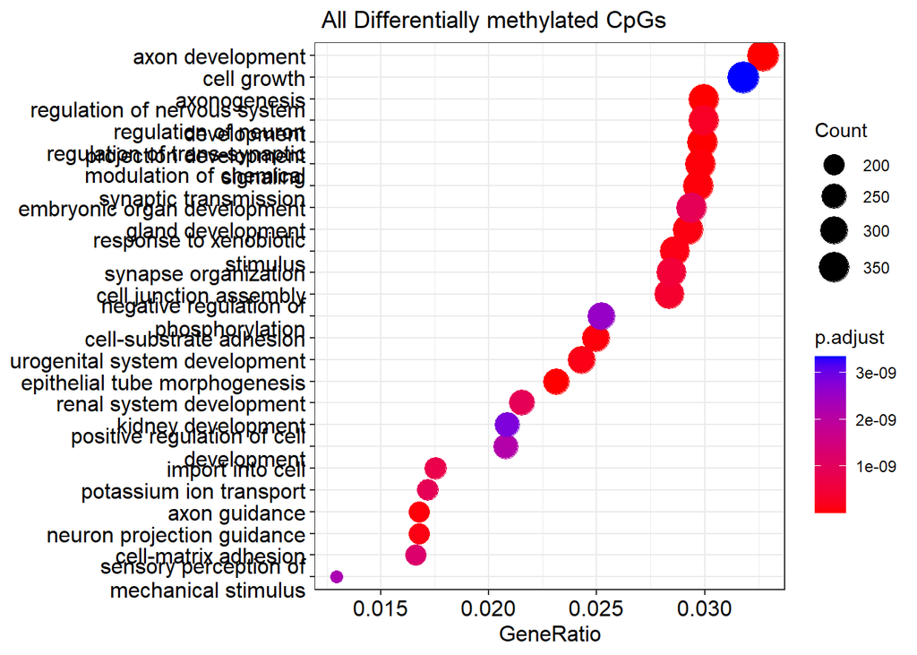

```r
genesid<-dmp_all$UCSC_RefGene_Name #Select the column where the Gene Name information is
genesid<- strsplit(as.character(genesid),';') #Split the column by the semicolon, as we can have different isoforms or different genes
genesid<-unique(unlist(genesid))#Select the unique names
genesid<-genesid[ genesid != "" ]##remove empty elements from a vector, so remove CpG that do not have any gene annotated
genesid <- genesid[!is.na(genesid)]

eg<-bitr(genesid, fromType="SYMBOL", toType="ENTREZID", OrgDb="org.Hs.eg.db")#convert gene symbols in the "genesid" object to Entrez IDs using the "bitr" function.

#Perform gene ontology (GO) enrichment analysis on a set of genes represented by their Entrez IDs.
eGO_dmp <- enrichGO(gene         = eg$ENTREZID,
                 OrgDb         = org.Hs.eg.db,
                 keyType       = 'ENTREZID',
                 ont           = "BP",
                 pAdjustMethod = "BH",
                 pvalueCutoff  = 0.05,
                 qvalueCutoff  = 0.05,
                 readable=T
)

#create a dot plot of the results of the GO enrichment analysis.
dotplot(eGO_dmp, title=" All Differentially methylated CpGs ",showCategory=25)
```

The resulting plot shows a dot for each enriched GO term, with the size of the dot representing the number of genes associated with the term, and the color representing the significance of the enrichment. The y-axis shows the top 25 enriched GO terms, in which we can find terms related with the development of specific organs, chemical signaling, cell adhesion…

```r
dim(eGO_dmp)
```

```
## [1] 1656    9
```

In this case, the typical GO enrichment analysis has found 1656 processes related with Crohn’s disease.

### 6.1.2 PROMS+ISLAND

Now, we will perform a GO enrichment analysis, but only of those Differentially Methylated CpGs positions that are found in promoter plus island regions. Follow the same steps than before.

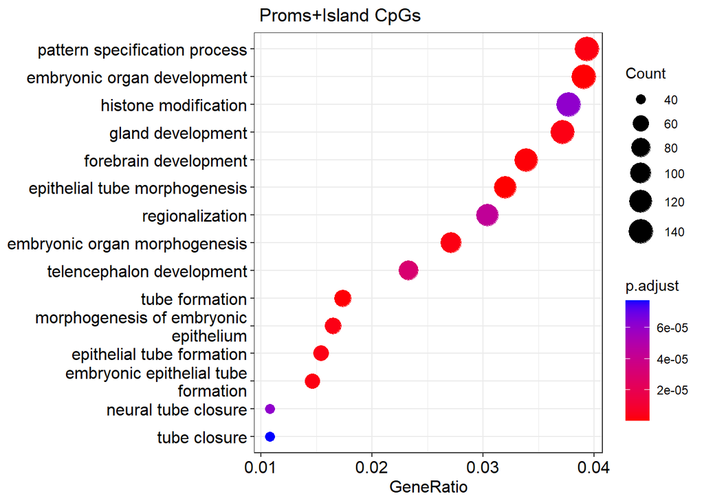

```r
genesid<-proms.island$UCSC_RefGene_Name#select the column that contains information about the genes that the CpG maps to.
genesid<- strsplit(as.character(genesid),';') #Split the column by the semicolon, as we can have different isoforms or different genes
genesid<-unique(unlist(genesid))#Select the unique names
genesid<-genesid[ genesid != "" ]##remove empty elements from a vector, so remove CpG that do not have any gene annotated
genesid <- genesid[!is.na(genesid)]

eg<-bitr(genesid, fromType="SYMBOL", toType="ENTREZID", OrgDb="org.Hs.eg.db")#convert gene symbols in the "genesid" object to Entrez IDs using the "bitr" function.
eGO_proms_island <- enrichGO(gene         = eg$ENTREZID,
                 OrgDb         = org.Hs.eg.db,
                 keyType       = 'ENTREZID',
                 ont           = "BP",
                 pAdjustMethod = "BH",
                 pvalueCutoff  = 0.05,
                 qvalueCutoff  = 0.05,
                 readable=T
)#Perform gene ontology (GO) enrichment analysis on a set of genes represented by their Entrez IDs.

dotplot(eGO_proms_island, title=" Proms+Island CpGs ",showCategory=15)
```

```r
dim(eGO_proms_island)
```

```
## [1] 358   9
```

After performing the GO enrichment analysis for only those DMP found in promoter plus island regions, we found 358 biological processes related with Crohn’s disease.

## 6.2 Missmethyl GO enrichment

From this Package, we will use the function *gometh()*, that takes as input a character vector of the names of the significant CpG sites previously obtained. We will start by performing a missmethyl GO enrichment analysis of all DMP and then we will perform another analysis focused in only those DMP found in promoter + island regions.

```r
library(missMethyl)
```

### 6.2.1 All dmp

```
## All input CpGs are used for testing.
```

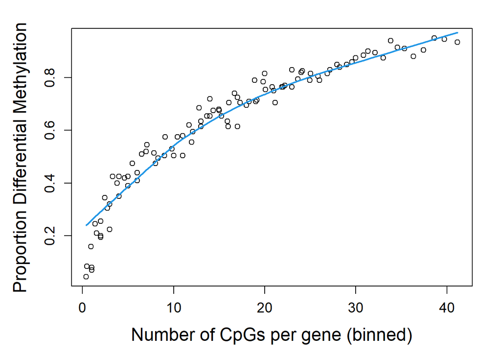

```r
# --- Missmethyl GO analysis ---
mismethyl_dmp <- gometh(rownames(dmp_all),all.cpg = rownames(betas),collection = "GO",
                        array.type = "EPIC",plot.bias = T,prior.prob = T,equiv.cpg = T,anno = ann850k)
```

The *gometh()* function takes into account the varying numbers of CpGs associated with each gene, and those that have more CpGs associated with them will have a higher probability of being identified as differentially methylated compared to genes with fewer CpGs. This bias in the data can be seen in this plot.

```r
#Subset the results of the previous step to only include those that are related to Biological Processes.
mismethyl_dmp<-mismethyl_dmp[mismethyl_dmp$ONTOLOGY=="BP",]

#Select the terms that are statistically significant
mismethyl_dmp<-mismethyl_dmp[mismethyl_dmp$P.DE<.05,]

#Ascending reorder the row based on the p-value column
mismethyl_dmp<-mismethyl_dmp[order(mismethyl_dmp$P.DE,decreasing = F),]

#Select the 25 top GO terms
topGSA(mismethyl_dmp, number=15)
```

```
##            ONTOLOGY                                          TERM    N   DE
## GO:0007275       BP            multicellular organism development 4711 3744
## GO:0048731       BP                            system development 4256 3387
## GO:0048856       BP              anatomical structure development 5677 4419
## GO:0032502       BP                         developmental process 6214 4785
## GO:0051179       BP                                  localization 5057 3930
## GO:0016043       BP               cellular component organization 5984 4631
## GO:0007399       BP                    nervous system development 2388 1946
## GO:0071840       BP cellular component organization or biogenesis 6184 4770
## GO:0009653       BP            anatomical structure morphogenesis 2685 2158
## GO:0065008       BP              regulation of biological quality 3588 2811
## GO:0006810       BP                                     transport 4301 3346
## GO:0051234       BP                 establishment of localization 4454 3462
## GO:0048513       BP                      animal organ development 3441 2708
## GO:0000902       BP                            cell morphogenesis  974  838
## GO:0048518       BP     positive regulation of biological process 6037 4618
##                    P.DE          FDR
## GO:0007275 2.851337e-28 6.503615e-24
## GO:0048731 5.748489e-26 6.555864e-22
## GO:0048856 1.375284e-22 5.228142e-19
## GO:0032502 3.191303e-19 7.279044e-16
## GO:0051179 6.527330e-19 1.353471e-15
## GO:0016043 1.806860e-18 3.173884e-15
## GO:0007399 1.808957e-18 3.173884e-15
## GO:0071840 6.730672e-18 1.023466e-14
## GO:0009653 1.370188e-17 1.953289e-14
## GO:0065008 3.129984e-17 3.966211e-14
## GO:0006810 3.467520e-17 3.977434e-14
## GO:0051234 3.487600e-17 3.977434e-14
## GO:0048513 4.342943e-17 4.717056e-14
## GO:0000902 1.422793e-16 1.475113e-13
## GO:0048518 1.958361e-16 1.942098e-13
```

```r
dim(mismethyl_dmp)
```

```
## [1] 1444    6
```

The missmethyl GO enrichment analysis has found 1444 terms associated with Crohn’s disease.

### 6.2.2 Proms+Islands

Next, it is performed a missmethyl GO enrichment of those DMP found in promoter plus island regions.

```
## All input CpGs are used for testing.
```

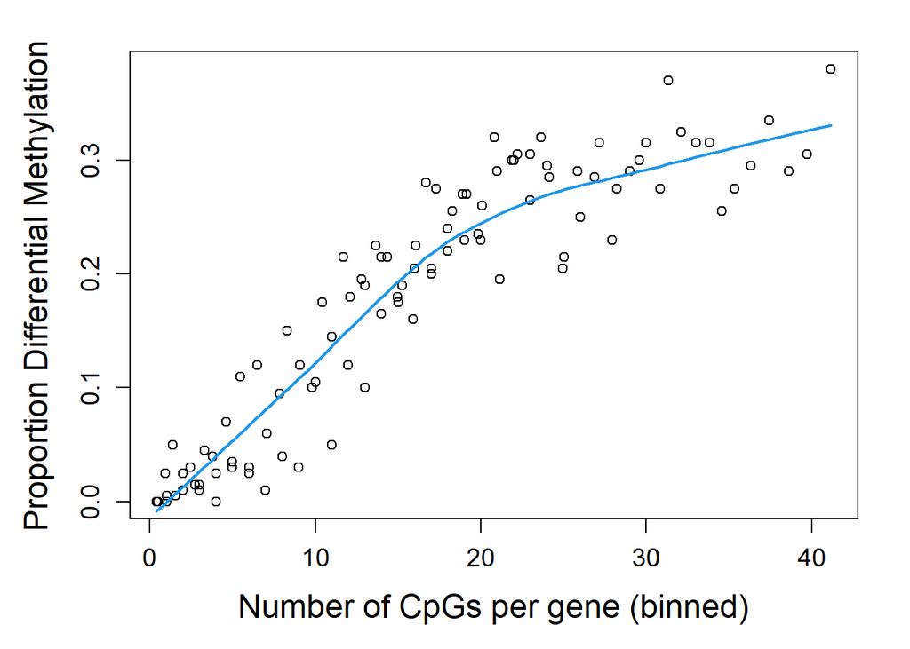

```r
# --- Missmethyl GO analysis ---
mismethyl_Proms_island <- gometh(rownames(proms.island),all.cpg = rownames(betas),collection = "GO",
                        array.type = "EPIC",plot.bias = T,prior.prob = T,equiv.cpg = T,anno = ann850k)
```

```r
#Subset the results of the previous step to only include those that are related to Biological Processes.
mismethyl_Proms_island<-mismethyl_Proms_island[mismethyl_Proms_island$ONTOLOGY=="BP",]

#Select the terms that are statistically significant
mismethyl_Proms_island<-mismethyl_Proms_island[mismethyl_Proms_island$P.DE<.05,]

#Ascending reorder the row based on the p-value column
mismethyl_Proms_island<-mismethyl_Proms_island[order(mismethyl_Proms_island$P.DE,decreasing = F),]

#Select the 25 top GO terms
topGSA(mismethyl_Proms_island, number=25)
```

```
##            ONTOLOGY
## GO:0044271       BP
## GO:0006139       BP
## GO:0006366       BP
## GO:0034641       BP
## GO:0019438       BP
## GO:0018130       BP
## GO:0034654       BP
## GO:0006351       BP
## GO:0090304       BP
## GO:0097659       BP
## GO:0032774       BP
## GO:0006725       BP
## GO:0044249       BP
## GO:0046483       BP
## GO:0009058       BP
## GO:0009059       BP
## GO:1901576       BP
## GO:1901362       BP
## GO:0071824       BP
## GO:0019219       BP
## GO:0051253       BP
## GO:0006355       BP
## GO:0045892       BP
## GO:2001141       BP
## GO:0051252       BP
##                                                                      TERM    N
## GO:0044271                cellular nitrogen compound biosynthetic process 4515
## GO:0006139               nucleobase-containing compound metabolic process 5639
## GO:0006366                             transcription by RNA polymerase II 2487
## GO:0034641                   cellular nitrogen compound metabolic process 6474
## GO:0019438                         aromatic compound biosynthetic process 3800
## GO:0018130                               heterocycle biosynthetic process 3787
## GO:0034654            nucleobase-containing compound biosynthetic process 3720
## GO:0006351                                    DNA-templated transcription 3298
## GO:0090304                                 nucleic acid metabolic process 5118
## GO:0097659                           nucleic acid-templated transcription 3300
## GO:0032774                                       RNA biosynthetic process 3315
## GO:0006725                   cellular aromatic compound metabolic process 5855
## GO:0044249                                  cellular biosynthetic process 5418
```

[output cut: 23 more lines]

```
## GO:0032774  920 1.633389e-07 1.379851e-04
## GO:0006725 1480 2.930332e-07 2.387070e-04
## GO:0044249 1429 6.577285e-07 5.000710e-04
## GO:0046483 1465 9.000180e-07 6.515279e-04
## GO:0009058 1464 9.140643e-07 6.515279e-04
## GO:0009059 1195 1.112757e-06 7.471152e-04
## GO:1901576 1444 1.113679e-06 7.471152e-04
## GO:1901362 1074 1.348742e-06 8.789557e-04
## GO:0071824   82 1.454219e-06 9.141590e-04
## GO:0019219 1036 1.482918e-06 9.141590e-04
## GO:0051253  400 1.565894e-06 9.399074e-04
## GO:0006355  882 2.420018e-06 1.401730e-03
## GO:0045892  369 2.458205e-06 1.401730e-03
## GO:2001141  884 2.774381e-06 1.467471e-03
## GO:0051252  957 2.799871e-06 1.467471e-03
```

```r
dim(mismethyl_Proms_island)
```

```
## [1] 459   6
```

The missmethyl GO enrichment in promoter plus island region analysis has found 459 terms associated with Crohn’s disease.

## 6.3 Biology of Crohn’s disease

Crohn’s disease is a type of inflammatory bowel disease that mainly causes inflammation in different parts of the gastrointestinal tract, which can lead to abdominal pain, severe diarrhea, malnutrition, and other conditions. Studies suggest that GO terms related to immune system, metabolic processes, cell differentiation, response to stimulus, regulation of nitrogen and development processes were the most enriched terms associated with patients suffering from Crohn’s disease (1,2).

All the enrichment analysis performed in this study contain more or less GO terms that are associated with the disease and suggested by other studies. The top terms obtained from the typical GO enrichment analysis (both DMP and Prom+island) seem to be very associated with development. It is seen that terms related to development processes where all significantly downregulated in Crohn’s disease (1), which may indicate a delayed growth or sexual development of patients with the disease (3). So, we obtained a lot of significant DMP that map to genes related with the development.

The disease is also related with metabolic processes terms (1), also found in the enrichments performed in this study. Inflammation is a process strongly linked to the generation of metabolites, specially to nitrogen (4,5). In the Missmethyl GO enrichment considering all the DMP, there were found a lot of significant terms that correspond to metabolism (such as positive regulation of cellular metabolic process), and specially to nitrogen (such as regulation of nitrogen compound metabolic process). So, there is an association of Crohn’s disease with nitrogen metabolism.

Moreover, we also identified terms related to the response to stimulus and to the immune system. Note that the terms related with immune system in general have a more large p-value (still under 0.05), and when ranking the terms, they will be in the middle-bottom part of the list, so they may not be as important and the terms related to metabolic processes, development processes, response, and cell differentiation.

Almost all the terms described will be found more or less in all the enrichment analysis performed, but the combination of the different GO terms that is more likely to the biology of the disease, is most represented in the analysis performed using the Missmethyl Package and with all the DMP CpG sites.

Next, we can see that the terms described above are found in the missmethyl + DMP enrichment analysis.

```r
#nitrogen and metabolic processes
head(mismethyl_dmp[grep('nitrogen',mismethyl_dmp$TERM),])
```

```
##            ONTOLOGY                                                       TERM
## GO:0051173       BP positive regulation of nitrogen compound metabolic process
## GO:1901564       BP                  organonitrogen compound metabolic process
## GO:0051171       BP          regulation of nitrogen compound metabolic process
## GO:0071705       BP                                nitrogen compound transport
## GO:0051172       BP negative regulation of nitrogen compound metabolic process
## GO:0010243       BP                        response to organonitrogen compound
##               N   DE         P.DE          FDR
## GO:0051173 3019 2346 1.312135e-10 3.480058e-08
## GO:1901564 6193 4619 1.711203e-08 2.518117e-06
## GO:0051171 5415 4063 1.880281e-08 2.703927e-06
## GO:0071705 1930 1486 1.188270e-05 8.549925e-04
## GO:0051172 2327 1759 5.341082e-05 3.094959e-03
## GO:0010243 1012  788 1.781726e-04 8.277546e-03
```

```r
head(mismethyl_dmp[grep('metabolic',mismethyl_dmp$TERM),])
```

```
##            ONTOLOGY                                                       TERM
## GO:0009893       BP                   positive regulation of metabolic process
## GO:0051173       BP positive regulation of nitrogen compound metabolic process
## GO:0031325       BP          positive regulation of cellular metabolic process
## GO:0010604       BP     positive regulation of macromolecule metabolic process
## GO:0031323       BP                   regulation of cellular metabolic process
## GO:0080090       BP                    regulation of primary metabolic process
##               N   DE         P.DE          FDR
## GO:0009893 3699 2851 2.161395e-11 6.847119e-09
## GO:0051173 3019 2346 1.312135e-10 3.480058e-08
## GO:0031325 2982 2318 1.556307e-10 3.944200e-08
## GO:0010604 3394 2616 2.251876e-10 5.522906e-08
## GO:0031323 5363 4038 5.422452e-09 9.513901e-07
## GO:0080090 5571 4178 1.366526e-08 2.106020e-06
```

```r
#cell differentiation
head(mismethyl_dmp[grep('differentiation',mismethyl_dmp$TERM),])
```

```
##            ONTOLOGY                                                  TERM    N
## GO:0030182       BP                                neuron differentiation 1327
## GO:0030154       BP                                  cell differentiation 4120
## GO:0000904       BP        cell morphogenesis involved in differentiation  690
## GO:0048667       BP cell morphogenesis involved in neuron differentiation  537
## GO:0045595       BP                    regulation of cell differentiation 1574
## GO:0042692       BP                           muscle cell differentiation  398
##              DE         P.DE          FDR
## GO:0030182 1106 9.302033e-15 6.240296e-12
## GO:0030154 3183 3.742584e-13 1.778429e-10
## GO:0000904  591 5.157915e-11 1.547985e-08
## GO:0048667  464 7.369398e-10 1.600844e-07
## GO:0045595 1209 1.791518e-04 8.305435e-03
## GO:0042692  320 4.779190e-04 1.892509e-02
```

```r
#response to stimulus
head(mismethyl_dmp[grep('stimulus',mismethyl_dmp$TERM),])
```

```
##            ONTOLOGY                                        TERM    N   DE
## GO:0050896       BP                        response to stimulus 8453 6284
## GO:0051716       BP               cellular response to stimulus 7127 5325
## GO:0048583       BP          regulation of response to stimulus 3878 2976
## GO:0048584       BP positive regulation of response to stimulus 2117 1625
## GO:0070887       BP      cellular response to chemical stimulus 2990 2264
## GO:0009719       BP             response to endogenous stimulus 1577 1234
##                    P.DE          FDR
## GO:0050896 8.189240e-16 7.184169e-13
## GO:0051716 2.710179e-14 1.585038e-11
## GO:0048583 5.489608e-12 1.897159e-09
## GO:0048584 6.594589e-08 8.449634e-06
## GO:0070887 6.939855e-08 8.793953e-06
## GO:0009719 9.761386e-08 1.203500e-05
```

```r
#immune system
head(mismethyl_dmp[grep('immune',mismethyl_dmp$TERM),])
```

```
##            ONTOLOGY
## GO:0002376       BP
## GO:0002520       BP
## GO:0002764       BP
## GO:0002429       BP
## GO:0002757       BP
## GO:0002768       BP
##                                                                          TERM
## GO:0002376                                              immune system process
## GO:0002520                                          immune system development
## GO:0002764                       immune response-regulating signaling pathway
## GO:0002429 immune response-activating cell surface receptor signaling pathway
## GO:0002757                     immune response-activating signal transduction
## GO:0002768 immune response-regulating cell surface receptor signaling pathway
##               N   DE         P.DE        FDR
## GO:0002376 2487 1836 0.0002771225 0.01203978
## GO:0002520  990  759 0.0012867215 0.04174210
## GO:0002764  409  319 0.0022547213 0.06534681
## GO:0002429  229  180 0.0147003176 0.25673778
## GO:0002757  229  180 0.0147003176 0.25673778
## GO:0002768  257  199 0.0212545551 0.32870484
```

# 7 BIBLIOGRAPHY

1.Serena C, Millan M, Ejarque M, Saera-Vila A, Maymó-Masip E, Núñez-Roa C, Monfort-Ferré D, Terrón-Puig M, Bautista M, Menacho M, Martí M, Espin E, Vendrell J, Fernández-Veledo S. Adipose stem cells from patients with Crohn’s disease show a distinctive DNA methylation pattern. Clin Epigenetics. 2020 Apr 6;12(1):53. doi: 10.1186/s13148-020-00843-3. PMID: 32252817; PMCID: PMC7137346.

2.Garza-Hernandez, D., Sepulveda-Villegas, M., Garcia-Pelaez, J. et al. A systematic review and functional bioinformatics analysis of genes associated with Crohn’s disease identify more than 120 related genes. BMC Genomics 23, 302 (2022). https://doi.org/10.1186/s12864-022-08491-y

3.Crohn’s disease - Symptoms and causes - Mayo Clinic. Accessed March 24, 2023. https://www.mayoclinic.org/diseases-conditions/crohns-disease/symptoms-causes/syc-20353304

4.Kolios G, Valatas V, Ward SG. Nitric oxide in inflammatory bowel disease: a universal messenger in an unsolved puzzle. Immunology. 2004 Dec;113(4):427-37. doi: 10.1111/j.1365-2567.2004.01984.x. PMID: 15554920; PMCID: PMC1782592.

5.Ni J, Shen TD, Chen EZ, Bittinger K, Bailey A, Roggiani M, Sirota-Madi A, Friedman ES, Chau L, Lin A, Nissim I, Scott J, Lauder A, Hoffmann C, Rivas G, Albenberg L, Baldassano RN, Braun J, Xavier RJ, Clish CB, Yudkoff M, Li H, Goulian M, Bushman FD, Lewis JD, Wu GD. A role for bacterial urease in gut dysbiosis and Crohn’s disease. Sci Transl Med. 2017 Nov 15;9(416):eaah6888. doi: 10.1126/scitranslmed.aah6888. PMID: 29141885; PMCID: PMC5808452.